# BCR + GEX Integration Tutorial – Part 3: Repertoire Visualization

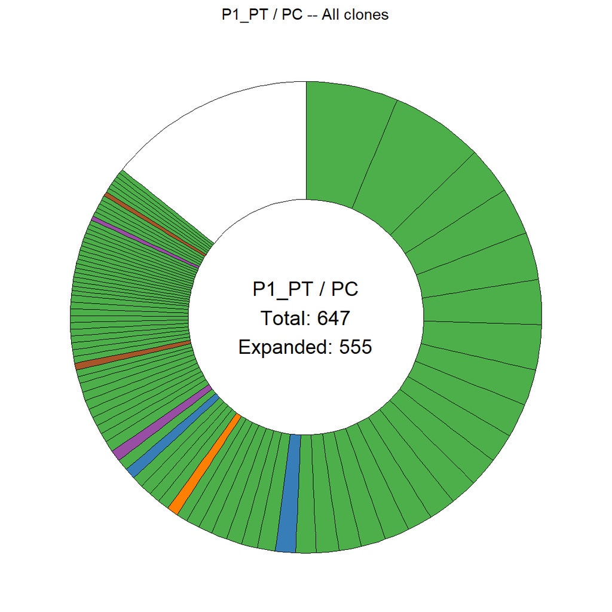

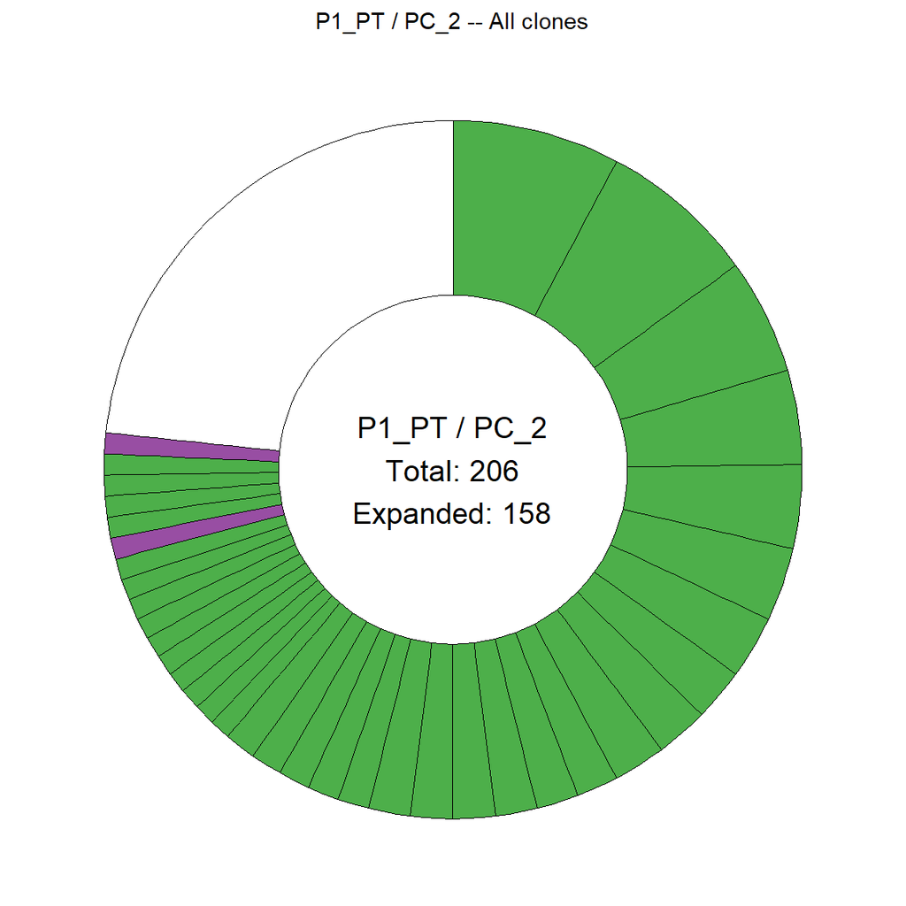

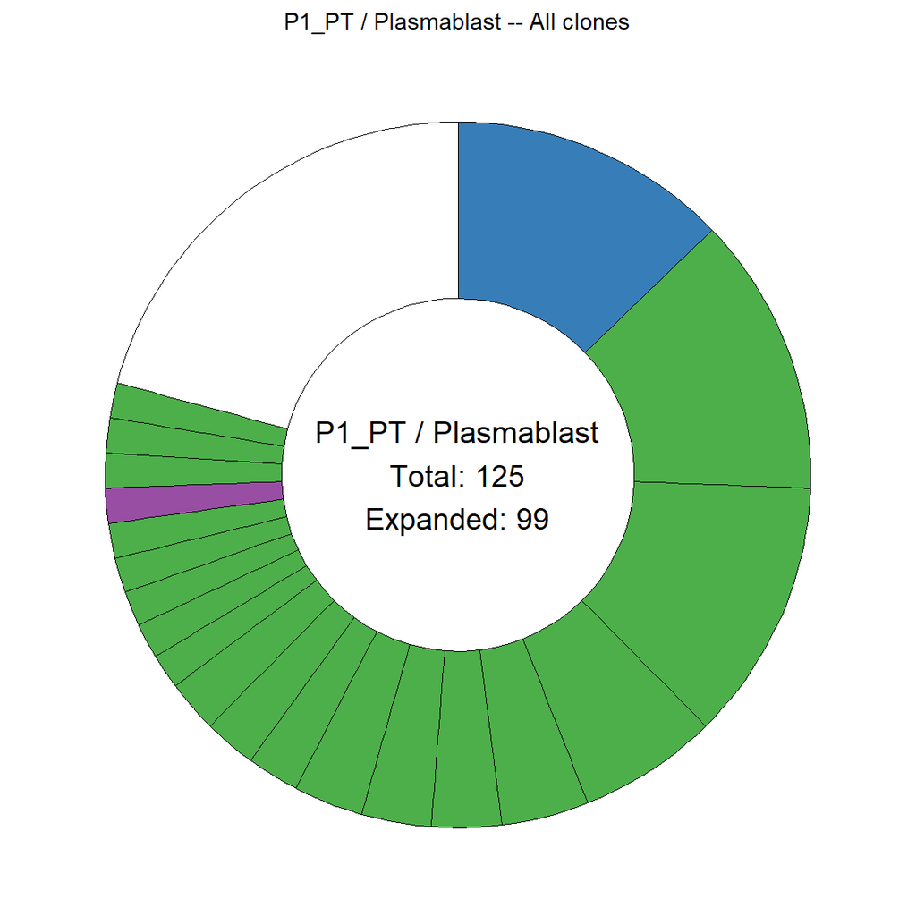

## 8.4 Phylogenetic trees

Phylogenetic trees reconstruct the evolutionary history of a B cell clone – how cells diversified from a common unmutated ancestor through rounds of somatic hypermutation in the germinal center. Unlike generic phylogenetic tools, dowser builds trees specifically designed for B cell clonal evolution. The key difference is that the unmutated germline sequence (reconstructed in Part 1 by `createGermlines()`) is used as the known root of the tree. This means the root is not inferred from the data but is fixed to the true biological ancestor, giving the tree a meaningful directionality: branch length represents mutations accumulated from the germline, and the root-to-tip direction represents time and affinity maturation.

Each tip represents one unique sequence (or a group of cells sharing an identical sequence, collapsed to reduce redundancy). Tip size reflects how many cells share that sequence. Tips are colored by isotype, showing how isotype switching occurred within the clone. Cell type labels are shown as colored rectangles next to tips where the cell type is known and at least two cells share that sequence – singleton tips are shown as points only to avoid cluttering small trees.

We build trees for the top 5 expanded clones per sample by default. You can change `top_n` or supply specific clone IDs via `clone_ids` to inspect particular clones of interest.

### 8.4a Cluster color palette

The tree tip labels use the same cell type color palette as the UMAP in Part 2.

```r
cluster_colors <- c(
  "MBC_Basal"    = "#F8766D",
  "MBC_Atypical" = "#D89000",
  "Naive"        = "#A3A500",
  "PC"           = "#39B600",
  "GC"           = "#00BF7D",
  "GC_Cycling"   = "#00BFC4",
  "MBC_CR2pos"   = "#00B0F6",
  "PC_2"         = "#9590FF",
  "Plasmablast"  = "#E76BF3",
  "Unsure"       = "#FF62BC"
)
```

### 8.4.1 Trees – P1_LN

```r
# If IQ-TREE 2 is not on your system PATH, supply the full path:
#   Windows : exec = "C:/tools/iqtree2/bin/iqtree2.exe"
#   macOS   : exec = "/usr/local/bin/iqtree2"

tree_plots_ln <- build_bcr_trees(
  bcr_data       = bcr_annotated[["P1_LN"]],
  cluster_colors = cluster_colors,
  top_n          = 5,
  cell_type_col  = "cell_type",
  exec           = "iqtree2"
)
```

```
## Attempting top 5 trees from a pool of 15 candidates (skipped clones will be replaced):
```

```
##   1. P1_LN_Yvk9_6_G2G4  (6 cells)
```

```
##   2. P1_LN_QPMs_5_A1  (5 cells)
```

```
##   3. P1_LN_XcB7_4_A1  (4 cells)
```

```
##   4. P1_LN_0zZk_3_G1  (3 cells)
```

```
##   5. P1_LN_APab_3_A1G1  (3 cells)
```

```
##   6. P1_LN_CTVF_3_A1  (3 cells)
```

```
##   7. P1_LN_G28h_3_A1  (3 cells)
```

```
##   8. P1_LN_XvdZ_3_A1A2  (3 cells)
```

```
##   9. P1_LN_icBg_3_A2G1  (3 cells)
```

```
##   10. P1_LN_r1ZB_3_A2  (3 cells)
```

```
##   ... and 5 more
```

```
## Building tree for clone: P1_LN_Yvk9_6_G2G4
```

```
##   Chain type: HL | Sequences: 12
```

```
##   Building tree on 6 cells
```

```
##   Running IQ-TREE 2...
```

```
##   Tree built successfully.
```

```
##   Plot created.
```

```
## Building tree for clone: P1_LN_QPMs_5_A1
```

```
##   Chain type: HL | Sequences: 10
```

```
##   Building tree on 5 cells
```

```
##   Skipping -- all 5 cells share the same heavy chain VDJ sequence. No phylogenetic signal to build a tree from (clonal expansion with no further SHM).
```

```
## Building tree for clone: P1_LN_XcB7_4_A1
```

```
##   Chain type: HL | Sequences: 8
```

```
##   Building tree on 4 cells
```

```
##   Skipping -- all 4 cells share the same heavy chain VDJ sequence. No phylogenetic signal to build a tree from (clonal expansion with no further SHM).
```

```
## Building tree for clone: P1_LN_0zZk_3_G1
```

```
##   Chain type: HL | Sequences: 6
```

```
##   Building tree on 3 cells
```

```
##   Running IQ-TREE 2...
```

```
##   Tree built successfully.
```

```
##   Plot created.
```

```
## Building tree for clone: P1_LN_APab_3_A1G1
```

```
##   Chain type: HL | Sequences: 6
```

```
##   Building tree on 3 cells
```

```
##   Running IQ-TREE 2...
```

```
##   Tree built successfully.
```

```
##   Plot created.
```

```
## Building tree for clone: P1_LN_CTVF_3_A1
```

```
##   Chain type: HL | Sequences: 6
```

```
##   Building tree on 3 cells
```

```
##   Running IQ-TREE 2...
```

```
##   Tree built successfully.
```

```
##   Plot created.
```

```
## Building tree for clone: P1_LN_G28h_3_A1
```

```
##   Chain type: HL | Sequences: 6
```

```
##   Building tree on 3 cells
```

```
##   Skipping -- all 3 cells share the same heavy chain VDJ sequence. No phylogenetic signal to build a tree from (clonal expansion with no further SHM).
```

```
## Building tree for clone: P1_LN_XvdZ_3_A1A2
```

```
##   Chain type: HL | Sequences: 6
```

```
##   Building tree on 3 cells
```

```
##   Running IQ-TREE 2...
```

```
##   Tree built successfully.
```

```
##   Plot created.
```

```
##   Reached target of 5 successful trees. Stopping.
```

```
## build_bcr_trees complete.
```

```
## Trees built successfully: 5 / 5
```

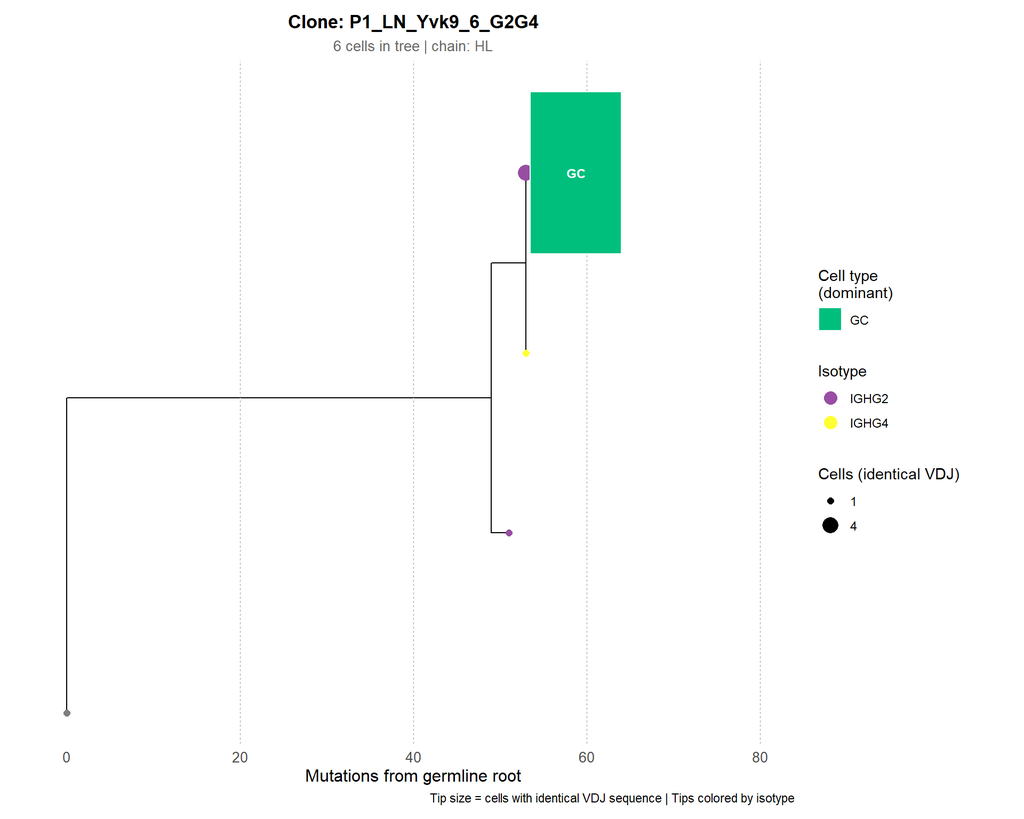

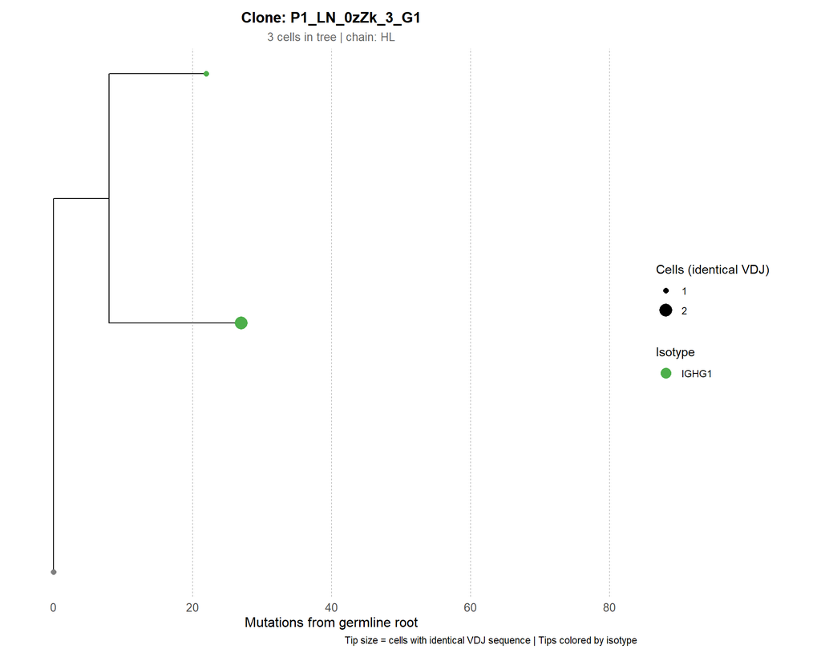

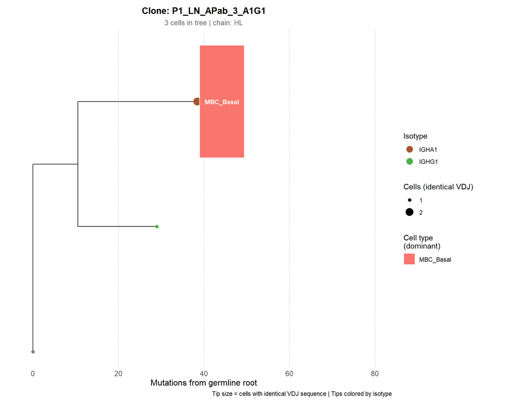

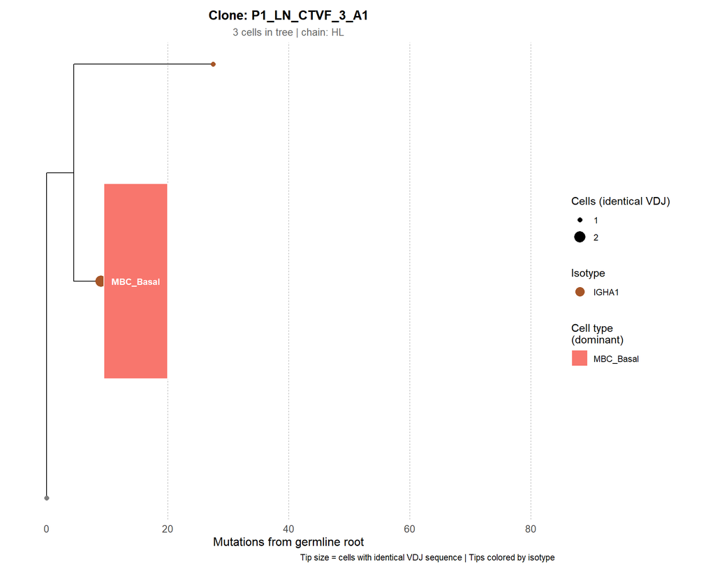

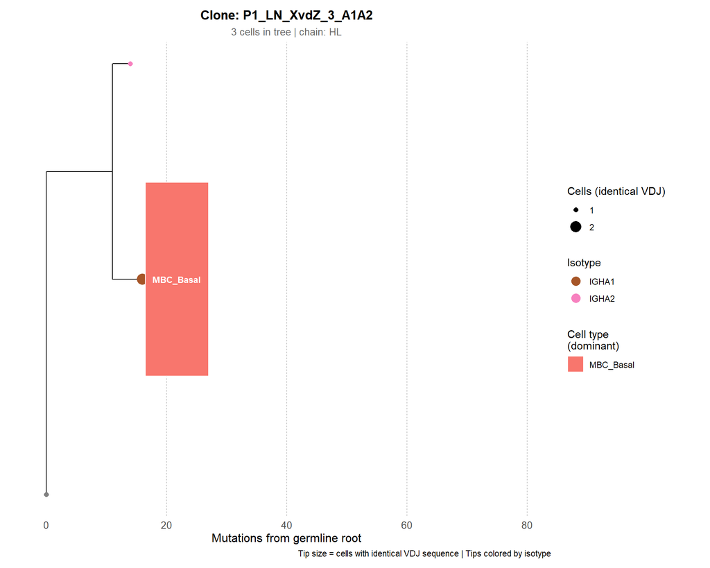

```r
for (cid in names(tree_plots_ln)) {
  if (!is.null(tree_plots_ln[[cid]])) {
    print(tree_plots_ln[[cid]])
  }
}
```

### 8.4.2 Trees – P1_PT

```r
tree_plots_pt <- build_bcr_trees(
  bcr_data       = bcr_annotated[["P1_PT"]],
  cluster_colors = cluster_colors,
  top_n          = 5,
  cell_type_col  = "cell_type",
  exec           = "iqtree2"
)
```

```
## Attempting top 5 trees from a pool of 15 candidates (skipped clones will be replaced):
```

```
##   1. P1_PT_dyZf_138_G1G2  (138 cells)
```

```
##   2. P1_PT_VA3i_127_A1A2G1G2G3M  (127 cells)
```

```
##   3. P1_PT_Skl5_107_G1G2G3  (107 cells)
```

```
##   4. P1_PT_rf2S_92_G1G3M  (92 cells)
```

```
##   5. P1_PT_0L1W_81_G1G2  (81 cells)
```

```
##   6. P1_PT_TYVg_74_A1DG1G2G3M  (74 cells)
```

```
##   7. P1_PT_0BNp_61_DG1G2G3  (61 cells)
```

```
##   8. P1_PT_NvVP_61_G1G3  (61 cells)
```

```
##   9. P1_PT_zvKr_58_G1G2G3M  (58 cells)
```

```
##   10. P1_PT_bBK0_57_G1  (57 cells)
```

```
##   ... and 5 more
```

```
## Building tree for clone: P1_PT_dyZf_138_G1G2
```

```
##   Chain type: HL | Sequences: 273
```

```
##   Building tree on 135 cells (3 removed: no isotype call or unpaired light chain)
```

```
##   Running IQ-TREE 2...
```

```
##   Tree built successfully.
```

```
##   Plot created.
```

```
## Building tree for clone: P1_PT_VA3i_127_A1A2G1G2G3M
```

```
##   Chain type: HL | Sequences: 245
```

```
##   Removed 2 cells: heavy chain present but no paired light chain
```

```
##   Building tree on 118 cells (9 removed: no isotype call or unpaired light chain)
```

```
##   Running IQ-TREE 2...
```

```
##   Tree built successfully.
```

```
##   Plot created.
```

```
## Building tree for clone: P1_PT_Skl5_107_G1G2G3
```

```
##   Chain type: HL | Sequences: 214
```

```
##   Building tree on 107 cells
```

```
##   Running IQ-TREE 2...
```

```
##   Tree built successfully.
```

```
##   Plot created.
```

```
## Building tree for clone: P1_PT_rf2S_92_G1G3M
```

```
##   Chain type: HL | Sequences: 180
```

```
##   Removed 1 cells: heavy chain present but no paired light chain
```

```
##   Building tree on 88 cells (4 removed: no isotype call or unpaired light chain)
```

```
##   Running IQ-TREE 2...
```

```
##   Tree built successfully.
```

```
##   Plot created.
```

```
## Building tree for clone: P1_PT_0L1W_81_G1G2
```

```
##   Chain type: HL | Sequences: 158
```

```
##   Building tree on 77 cells (4 removed: no isotype call or unpaired light chain)
```

```
##   Running IQ-TREE 2...
```

```
##   Tree built successfully.
```

```
##   Plot created.
```

```
##   Reached target of 5 successful trees. Stopping.
```

```
## build_bcr_trees complete.
```

```
## Trees built successfully: 5 / 5
```

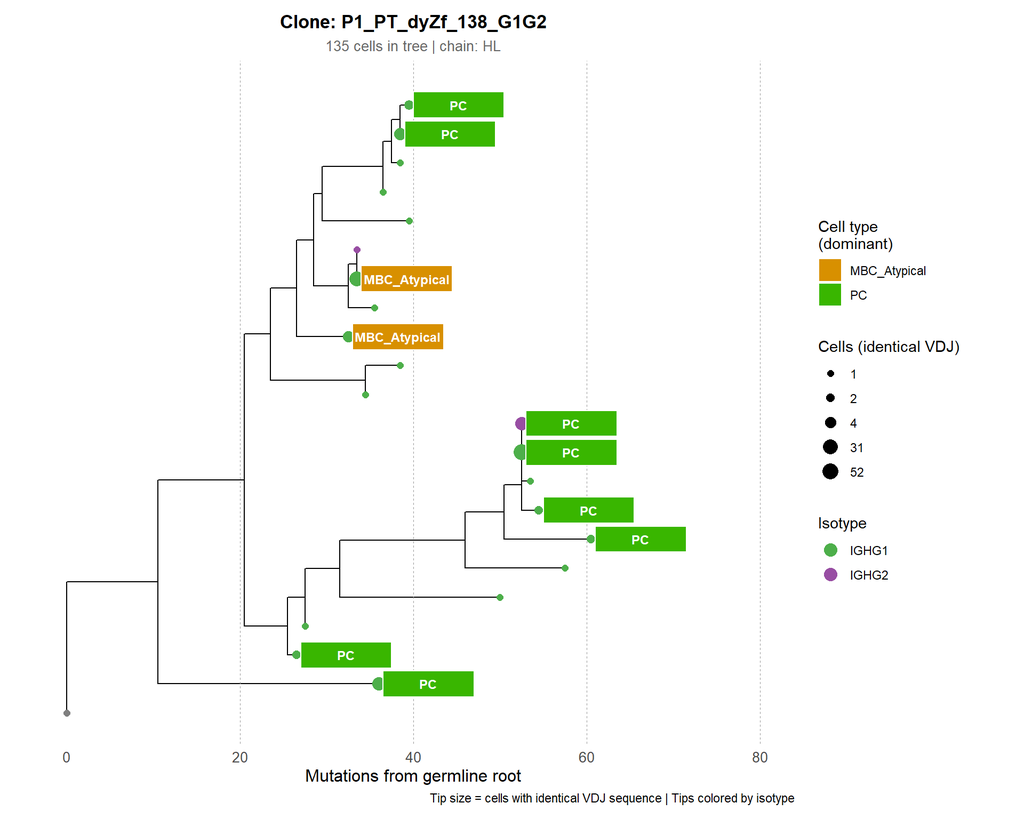

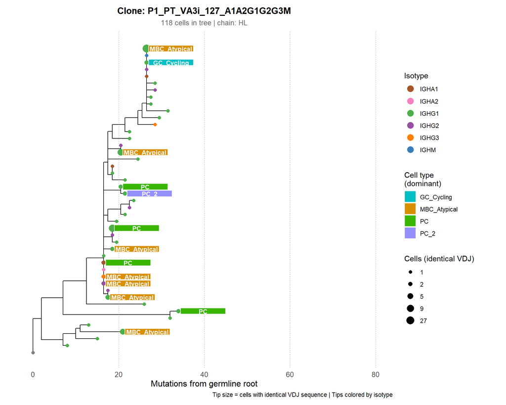

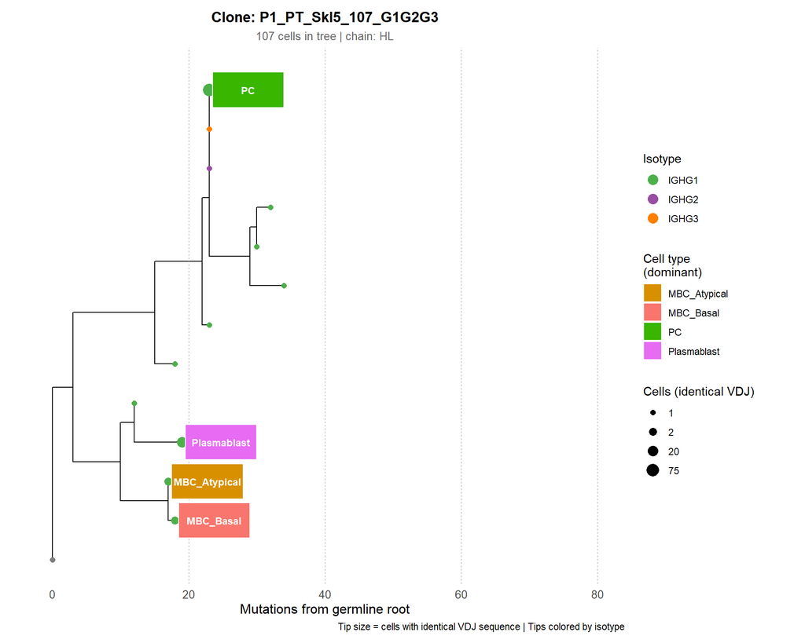

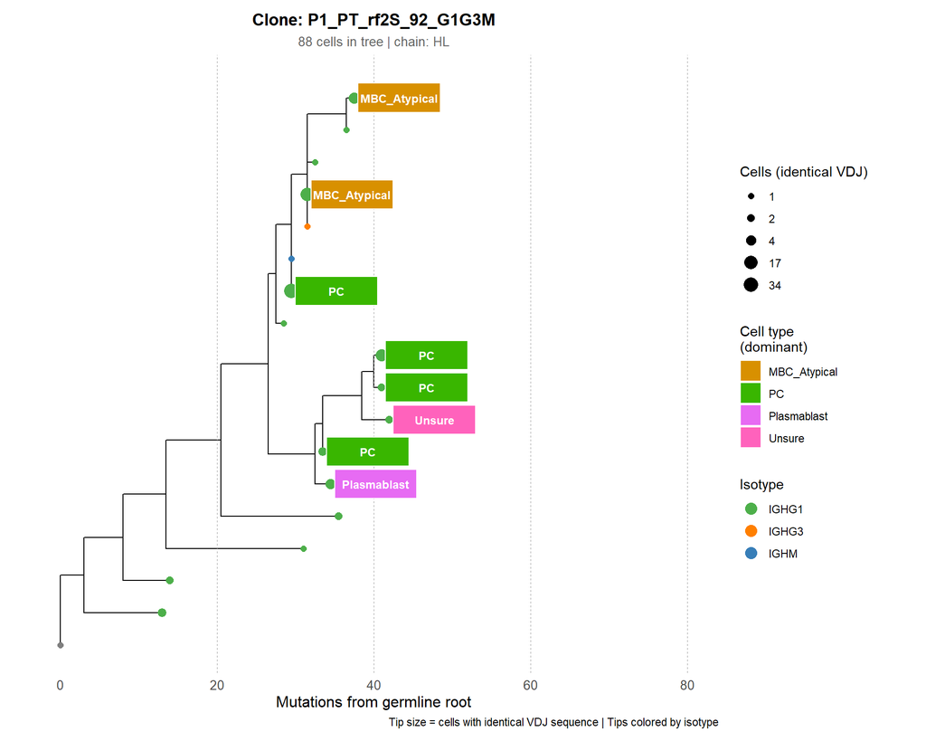

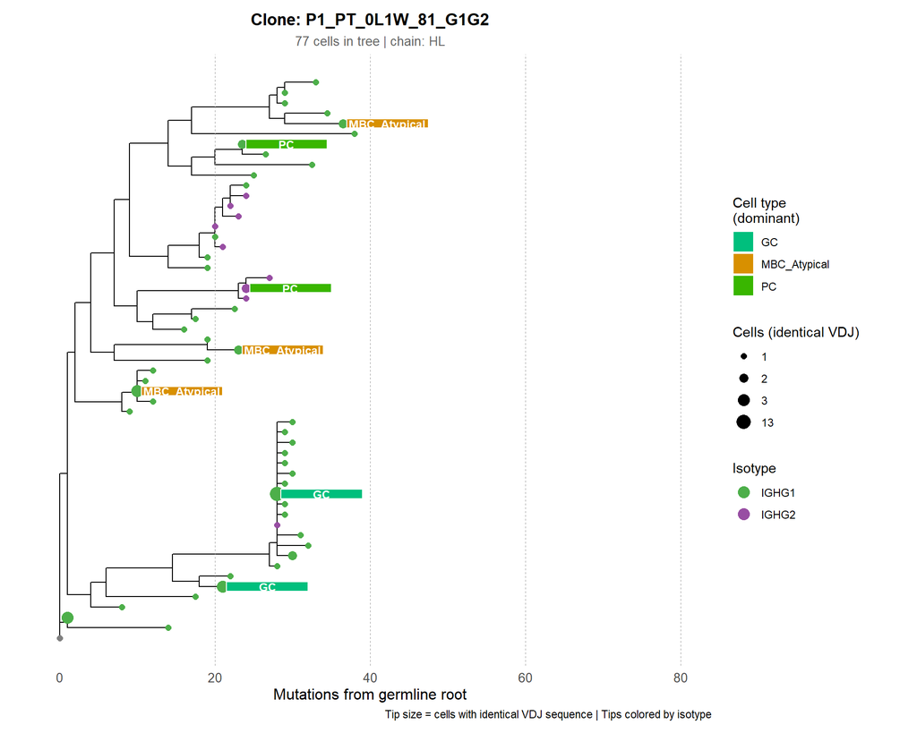

```r
for (cid in names(tree_plots_pt)) {
  if (!is.null(tree_plots_pt[[cid]])) {
    print(tree_plots_pt[[cid]])
  }
}
```

### 8.4.3 Building a tree for a specific clone

To build a tree for a particular clone of interest rather than the top N by size, supply the clone ID directly via the `clone_ids` argument. Clone IDs follow the format `<sample_id>_<random_code>_<clone_size>_<isotypes>` and can be found in the wide-format Excel table saved in Section 8.2b.

```r
# Replace with your clone ID of interest
target_clone <- "P1_LN_4aFs_6_G2G4"

tree_specific <- build_bcr_trees(
  bcr_data       = bcr_annotated[["P1_LN"]],
  cluster_colors = cluster_colors,
  clone_ids      = target_clone,
  cell_type_col  = "cell_type",
  exec           = "iqtree2"
)

print(tree_specific[[target_clone]])
```

[output not shown]

### 8.4.4 Save tree plots to PDF

```r
tree_dir <- file.path(plot_dir, "Trees")
dir.create(tree_dir, recursive = TRUE, showWarnings = FALSE)

for (sid in c("P1_LN", "P1_PT")) {
  plots <- if (sid == "P1_LN") tree_plots_ln else tree_plots_pt

  for (cid in names(plots)) {
    if (!is.null(plots[[cid]])) {
      out_file <- file.path(tree_dir, paste0(cid, "_tree.pdf"))
      ggplot2::ggsave(out_file, plots[[cid]], width = 10, height = 8)
      message("Saved: ", out_file)
    }
  }
}
```

```
## Saved: C:/Users/natha/OneDrive/Documents/Immcantation/BCR_Tutorial/Github/Plots/Part3/Trees/P1_LN_Yvk9_6_G2G4_tree.pdf
```

```
## Saved: C:/Users/natha/OneDrive/Documents/Immcantation/BCR_Tutorial/Github/Plots/Part3/Trees/P1_LN_0zZk_3_G1_tree.pdf
```

```
## Saved: C:/Users/natha/OneDrive/Documents/Immcantation/BCR_Tutorial/Github/Plots/Part3/Trees/P1_LN_APab_3_A1G1_tree.pdf
```

```
## Saved: C:/Users/natha/OneDrive/Documents/Immcantation/BCR_Tutorial/Github/Plots/Part3/Trees/P1_LN_CTVF_3_A1_tree.pdf
```

```
## Saved: C:/Users/natha/OneDrive/Documents/Immcantation/BCR_Tutorial/Github/Plots/Part3/Trees/P1_LN_XvdZ_3_A1A2_tree.pdf
```

```
## Saved: C:/Users/natha/OneDrive/Documents/Immcantation/BCR_Tutorial/Github/Plots/Part3/Trees/P1_PT_dyZf_138_G1G2_tree.pdf
```

```
## Saved: C:/Users/natha/OneDrive/Documents/Immcantation/BCR_Tutorial/Github/Plots/Part3/Trees/P1_PT_VA3i_127_A1A2G1G2G3M_tree.pdf
```

```
## Saved: C:/Users/natha/OneDrive/Documents/Immcantation/BCR_Tutorial/Github/Plots/Part3/Trees/P1_PT_Skl5_107_G1G2G3_tree.pdf
```

```
## Saved: C:/Users/natha/OneDrive/Documents/Immcantation/BCR_Tutorial/Github/Plots/Part3/Trees/P1_PT_rf2S_92_G1G3M_tree.pdf
```

```
## Saved: C:/Users/natha/OneDrive/Documents/Immcantation/BCR_Tutorial/Github/Plots/Part3/Trees/P1_PT_0L1W_81_G1G2_tree.pdf
```

```r
message("All tree plots saved.")
```

```
## All tree plots saved.
```

# Step 9: Cross-Sample Clonal Analysis with scRepertoire

The analyses in Step 8 are per-sample: clones were defined independently for each sample in Part 1, so a clone in P1_LN and a clone in P1_PT with identical V(D)J sequences are treated as separate lineages. Step 9 asks a different question: are any clones shared between the LN and PT samples from the same patient? To answer this we use scRepertoire, which applies a cross-sample clonotype definition (CTstrict) based on shared V gene usage and greater than 85% CDR3 nucleotide similarity. This is intentionally distinct from the Immcantation clone IDs used in Step 8. The two definitions serve different purposes and should not be mixed.

**A note on clonotype definitions:** scRepertoire’s CTstrict and Immcantation’s `hierarchicalClones()` are not equivalent. Immcantation uses a mixture-model distance threshold on full heavy-chain sequences with light-chain splitting; scRepertoire uses a fixed 85% CDR3 similarity cutoff. CTstrict is specifically designed for cross-sample comparison where you do not want to re-run Immcantation on the combined data. Do not replace the Immcantation clone IDs with CTstrict for within-sample analyses – they serve different purposes.

## 9.1 Prepare AIRR data for scRepertoire

scRepertoire’s `combineBCR()` expects a named list of data frames, one per sample, with specific column names. Our Immcantation AIRR data uses slightly different names (e.g. `cell_id` instead of `barcode`, `locus` instead of `chain`, `v_call` instead of `v_gene`). The function below maps between them.

Note that `cdr3` (amino acid) and `cdr3_nt` (nucleotide) are both mapped from the `junction` and `junction_aa` columns. scRepertoire uses `cdr3_nt` for the CTstrict distance calculation.

```r
prepare_for_scRepertoire <- function(df) {

  # barcode and sample identity
  if (!"barcode"   %in% names(df) && "cell_id"   %in% names(df)) df$barcode   <- df$cell_id
  if (!"sample"    %in% names(df) && "sample_id" %in% names(df)) df$sample    <- df$sample_id

  # chain locus
  if (!"chain"     %in% names(df) && "locus"     %in% names(df)) df$chain     <- df$locus

  # gene calls
  if (!"v_gene"    %in% names(df) && "v_call"    %in% names(df)) df$v_gene    <- df$v_call
  if (!"d_gene"    %in% names(df) && "d_call"    %in% names(df)) df$d_gene    <- df$d_call
  if (!"j_gene"    %in% names(df) && "j_call"    %in% names(df)) df$j_gene    <- df$j_call
  if (!"c_gene"    %in% names(df) && "c_call"    %in% names(df)) df$c_gene    <- df$c_call

  # CDR3 sequences -- scRepertoire uses cdr3 (aa) and cdr3_nt for CTstrict
  if (!"cdr3"      %in% names(df) && "junction_aa" %in% names(df)) df$cdr3    <- df$junction_aa
  if (!"cdr3_nt"   %in% names(df) && "junction"    %in% names(df)) df$cdr3_nt <- df$junction
  if (!"cdr3_aa"   %in% names(df) && "junction_aa" %in% names(df)) df$cdr3_aa <- df$junction_aa

  # UMI count as a reads proxy (optional but avoids NAs in scRepertoire internals)
  if (!"reads"     %in% names(df) && "umi_count"   %in% names(df)) df$reads   <- df$umi_count
  if (!"reads"     %in% names(df))                                  df$reads   <- 1L

  return(df)
}
```

Now load both samples, apply the mapping, and run `combineBCR()`. `removeMulti = TRUE` drops cells with more than one heavy chain (these were already filtered in Part 1, so this is a safety net only).

```r
# Load the annotated BCR TSVs saved in Section 8.2a
annotated_tsv <- list(
  P1_LN = file.path(out_dir, "P1_LN_S8_bcr_annotated.tsv"),
  P1_PT = file.path(out_dir, "P1_PT_S8_bcr_annotated.tsv")
)

airr_list <- lapply(annotated_tsv, function(path) {
  if (!file.exists(path)) stop("File not found: ", path)
  data.table::fread(path, sep = "\t", data.table = FALSE)
})

airr_list <- lapply(airr_list, prepare_for_scRepertoire)

# Quick check: confirm required columns are present
required_cols <- c("barcode", "chain", "v_gene", "j_gene", "cdr3_nt")
for (sid in names(airr_list)) {
  missing <- setdiff(required_cols, colnames(airr_list[[sid]]))
  if (length(missing) > 0)
    stop(sid, ": missing required columns after mapping: ",
         paste(missing, collapse = ", "))
}

message("Running combineBCR() across ", length(airr_list), " samples...")
```

```
## Running combineBCR() across 2 samples...
```

```r
# Note on barcode format: combineBCR() prepends the sample name to each
# barcode, producing e.g. "P1_LN_ACTGCTCA...-1_P1_LN". This double
# suffix/prefix is expected -- our cell_ids already carry the sample suffix
# from Part 1, and combineBCR() adds its own prefix on top. The ct_lookup
# step in 9.3.1 strips the leading prefix to recover the original cell_id
# format used throughout Parts 1-8.

combined_BCR <- combineBCR(
  airr_list,
  samples     = names(airr_list),
  removeNA    = FALSE,
  removeMulti = TRUE
)

# Confirm output
message("combineBCR() complete.")
```

```
## combineBCR() complete.
```

```r
message("Cells per sample:")
```

```
## Cells per sample:
```

```r
print(sapply(combined_BCR, nrow))
```

```
## P1_LN P1_PT
##  2373  4307
```

```r
message("Columns in combined_BCR output:")
```

```
## Columns in combined_BCR output:
```

```r
print(colnames(combined_BCR[[1]]))
```

```
##  [1] "barcode"  "sample"   "IGH"      "cdr3_aa1" "cdr3_nt1" "IGLC"
##  [7] "cdr3_aa2" "cdr3_nt2" "CTgene"   "CTnt"     "CTaa"     "CTstrict"
## [13] "cellType"
```

```r
message("Example CTstrict values (P1_LN):")
```

```
## Example CTstrict values (P1_LN):
```

```r
print(head(combined_BCR[["P1_LN"]]$CTstrict, 10))
```

```
##  [1] "IGH.247.IGHV3-23*01,IGHV3-23D*01_IGLC:LD.5.IGLV2-14*03"
##  [2] "IGH.1244.IGHV3-30-3*01_IGLC:LD.5.IGLV2-14*03"
##  [3] "IGH.292.IGHV3-30-3*01_IGLC.42.IGLV2-14*03"
##  [4] "IGH.690.IGHV3-21*02_IGLC:LD.5.IGLV2-8*01"
##  [5] "IGH.690.IGHV3-21*02_IGLC:LD.5.IGLV2-8*01"
##  [6] "IGH:LD.731.IGHV4-30-2*01_IGLC.82.IGLV2-14*01,IGLV2-14*03"
##  [7] "IGH.1525.IGHV1-3*01_IGLC.187.IGLV1-44*01"
##  [8] "IGH.1455.IGHV1-2*02_IGLC:LD.5.IGLV2-18*02"
##  [9] "IGH.1967.IGHV3-9*01_IGLC:LD.5.IGLV2-14*01,IGLV2-14*03"
## [10] "IGH:LD.1510.IGHV3-23*01,IGHV3-23D*01_IGLC:LD.5.IGLV2-18*02"
```

```r
# Save
saveRDS(combined_BCR, file.path(rds_dir, "combined_BCR_S9.rds"))
message("Saved: combined_BCR_S9.rds")
```

```
## Saved: combined_BCR_S9.rds
```

## 9.2 Repertoire-level characterization

Before looking at shared clones, we characterize each sample’s repertoire structure independently.

### 9.2.1 Clonal homeostasis

`clonalHomeostasis()` shows what fraction of each sample’s repertoire is occupied by clones in different size classes. Each bar represents one sample; the stacked segments represent the proportion of cells belonging to rare, small, medium, large, and hyperexpanded clones. This gives an immediate read of how oligoclonal each repertoire is.

For B cell data the default proportional bins (Rare < 0.0001, Small < 0.001, Medium < 0.01, Large < 0.1, Hyperexpanded < 1) are appropriate.

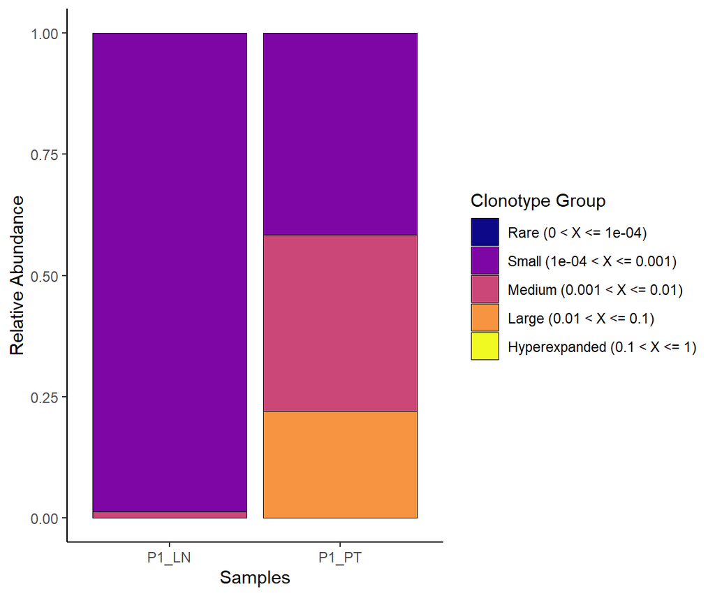

```r
p_homeostasis <- clonalHomeostasis(
  combined_BCR,
  cloneCall = "strict"
)

p_homeostasis
```

```r
ggsave(file.path(plot_dir, "clonal_homeostasis.pdf"),
       p_homeostasis, width = 6, height = 5)
message("Saved: clonal_homeostasis.pdf")
```

```
## Saved: clonal_homeostasis.pdf
```

## 9.3 Quantify shared clones

Here we break down the repertoire overlap into specific numbers: how many CTstrict clones are shared between LN and PT, and how many cells belong to those shared clones. We also build a master table that joins CTstrict onto the per-cell BCR data from Step 8.

**A note on method and reproducibility:** This tutorial uses pure CTstrict for both identifying shared clones and counting cells within them. If you compare these numbers against a paper that used a hybrid approach – using CTstrict to identify shared clones but Immcantation `clone_id` to count cells – you will get different totals. Immcantation groups cells more aggressively than CTstrict, so the hybrid approach typically counts more cells per shared clone. Neither is wrong; they answer slightly different questions. The pure CTstrict approach used here is more reproducible because it depends only on scRepertoire.

### 9.3.1 Build the CTstrict lookup

`combineBCR()` prepends the sample name to each barcode (e.g. `P1_LN_ACGT...-1_P1_LN`). The BCR data from Step 8 uses `cell_id` in the format `ACGT...-1_P1_LN`. We strip the leading `<sample>_` prefix from the combined_BCR barcodes so they match the Step 8 cell_id format.

```r
ct_lookup <- do.call(rbind, lapply(names(combined_BCR), function(sid) {
  df <- combined_BCR[[sid]]
  data.frame(
    sample_id = df$sample,
    # Remove the leading "<sample>_" prefix that combineBCR adds
    cell_id   = sub(paste0("^", sid, "_"), "", df$barcode),
    CTstrict  = df$CTstrict,
    CTaa      = df$CTaa,
    CTnt      = df$CTnt,
    CTgene    = df$CTgene,
    stringsAsFactors = FALSE
  )
}))

message("CTstrict lookup: ", nrow(ct_lookup), " rows")
```

```
## CTstrict lookup: 6680 rows
```

```r
message("Example cell_id values after stripping:")
```

```
## Example cell_id values after stripping:
```

```r
print(head(ct_lookup$cell_id, 6))
```

```
## [1] "ACTGCTCAGTAACCCT-1_P1_LN" "GCGCCAAGTAGCGTCC-1_P1_LN"
## [3] "AGCAGCCGTGCATCTA-1_P1_LN" "CCCAATCTCACGATGT-1_P1_LN"
## [5] "CGGACGTTCGAGGTAG-1_P1_LN" "CCACGGAGTTCGTTGA-1_P1_LN"
```

### 9.3.2 Join CTstrict onto the master BCR table

Load both annotated BCR TSVs from Step 8, combine them, and join the CTstrict column. This master table is the single input for the shared clone dot plot in Step 9.6.

```r
bcr_all <- do.call(rbind, lapply(names(annotated_tsv), function(sid) {
  data.table::fread(annotated_tsv[[sid]], sep = "\t", data.table = FALSE)
}))

message("Master BCR table: ", nrow(bcr_all), " rows | ",
        length(unique(bcr_all$cell_id[bcr_all$locus == "IGH"])),
        " cells with heavy chain")
```

```
## Master BCR table: 13299 rows | 6680 cells with heavy chain
```

```r
# Left-join CTstrict by sample_id + cell_id
bcr_all <- dplyr::left_join(
  bcr_all,
  ct_lookup,
  by = c("sample_id", "cell_id")
)

# Check match rate
n_igh     <- sum(bcr_all$locus == "IGH")
n_matched <- sum(!is.na(bcr_all$CTstrict[bcr_all$locus == "IGH"]))
message("CTstrict matched: ", n_matched, " / ", n_igh,
        " heavy chain cells (",
        round(100 * n_matched / n_igh, 1), "%)")
```

```
## CTstrict matched: 6680 / 6680 heavy chain cells (100%)
```

```r
# If the match rate is below 50%, check that the barcode format is consistent
# between Part 1 and Part 2. The cell_id in Step 8 should look like
# "ACGT...-1_P1_LN" and the stripped combined_BCR barcode should match exactly.
if (n_matched / n_igh < 0.5) {
  warning("Less than 50% of heavy chain cells matched a CTstrict. ",
          "Check barcode format consistency between Part 1 and Part 2.")
}

# Save
data.table::fwrite(bcr_all,
                   file.path(out_dir, "All_S9_bcr_with_CTstrict.tsv"),
                   sep = "\t")
message("Saved: All_S9_bcr_with_CTstrict.tsv")
```

```
## Saved: All_S9_bcr_with_CTstrict.tsv
```

### 9.3.3 Count shared clones and cells

```r
# Tissue label (LN or PT) derived from sample_id
bcr_all <- bcr_all %>%
  dplyr::mutate(
    tissue = dplyr::case_when(
      grepl("_LN$|^LN", sample_id) ~ "LN",
      grepl("_PT$|^PT", sample_id) ~ "PT",
      TRUE ~ "UNK"
    )
  )

# Restrict to heavy chain rows with a valid CTstrict
bcr_igh <- bcr_all %>%
  dplyr::filter(locus == "IGH", !is.na(CTstrict), CTstrict != "")

# Which CTstrict clones appear in both LN and PT?
clones_ln <- unique(bcr_igh$CTstrict[bcr_igh$tissue == "LN"])
clones_pt <- unique(bcr_igh$CTstrict[bcr_igh$tissue == "PT"])
shared_cts <- intersect(clones_ln, clones_pt)

message("CTstrict clones in LN only:   ", length(setdiff(clones_ln, clones_pt)))
```

```
## CTstrict clones in LN only:   2163
```

```r
message("CTstrict clones in PT only:   ", length(setdiff(clones_pt, clones_ln)))
```

```
## CTstrict clones in PT only:   1589
```

```r
message("CTstrict clones shared LN+PT: ", length(shared_cts))
```

```
## CTstrict clones shared LN+PT: 29
```

```r
# Cells per tissue belonging to shared clones
# (raw counts only -- no percentages; denominator choice is non-trivial)
cells_ln_shared <- sum(bcr_igh$CTstrict[bcr_igh$tissue == "LN"] %in% shared_cts)
cells_pt_shared <- sum(bcr_igh$CTstrict[bcr_igh$tissue == "PT"] %in% shared_cts)

message("LN cells in shared clones:    ", cells_ln_shared)
```

```
## LN cells in shared clones:    34
```

```r
message("PT cells in shared clones:    ", cells_pt_shared)
```

```
## PT cells in shared clones:    117
```

```r
message("Total shared cells:           ", cells_ln_shared + cells_pt_shared)
```

```
## Total shared cells:           151
```

```r
# Summary table of shared clones with cell counts per tissue
shared_clone_tbl <- bcr_igh %>%
  dplyr::filter(CTstrict %in% shared_cts) %>%
  dplyr::count(CTstrict, tissue, name = "n_cells") %>%
  tidyr::pivot_wider(
    names_from  = tissue,
    values_from = n_cells,
    values_fill = 0L
  ) %>%
  dplyr::mutate(total_cells = LN + PT) %>%
  dplyr::arrange(dplyr::desc(total_cells))

message("\nShared clone table (top 10):")
```

```
##
## Shared clone table (top 10):
```

```r
print(knitr::kable(head(shared_clone_tbl, 10), caption = "Top 10 shared clones by total cell count"))
```

```
##
##
## Table: Top 10 shared clones by total cell count
##
## |CTstrict                                                    | LN| PT| total_cells|
## |:-----------------------------------------------------------|--:|--:|-----------:|
## |IGH:LD.1809.IGHV3-30*18,IGHV3-30-5*01_IGLC.206.IGKV1-5*01   |  1| 54|          55|
## |IGH:LD.1671.IGHV3-30*18,IGHV3-30-5*01_IGLC:LD.3.IGLV1-51*02 |  1| 23|          24|
## |IGH:LD.1858.IGHV5-51*03_IGLC:LD.1.IGKV3-11*01               |  1| 12|          13|
## |IGH:LD.134.IGHV2-5*02_IGLC:LD.27.IGLV5-45*01                |  2|  3|           5|
## |IGH.16.IGHV4-61*12_IGLC.3.IGLV2-14*03                       |  3|  1|           4|
## |IGH:LD.1050.IGHV1-2*02_IGLC:LD.1.IGKV3-15*01                |  2|  1|           3|
## |IGH:LD.665.IGHV5-51*01_IGLC:LD.5.IGLV2-23*02                |  2|  1|           3|
## |IGH.1404.IGHV3-33*01_IGLC.169.IGLV3-21*04                   |  1|  1|           2|
## |IGH.1661.IGHV4-30-4*09,IGHV4-31*03_IGLC:LD.5.IGLV2-14*03    |  1|  1|           2|
## |IGH.1942.IGHV2-5*02_IGLC:LD.5.IGLV2-8*01                    |  1|  1|           2|
```

### 9.3.4 Visualize shared vs. exclusive cell counts

With only two samples, summary statistics like the Morisita overlap index reduce to a single number and are not informative as a standalone plot. Instead, we show a stacked bar chart of cell counts broken down by tissue and sharing status: how many IGH cells in each sample belong to tissue-exclusive clones vs. clones shared with the other tissue.

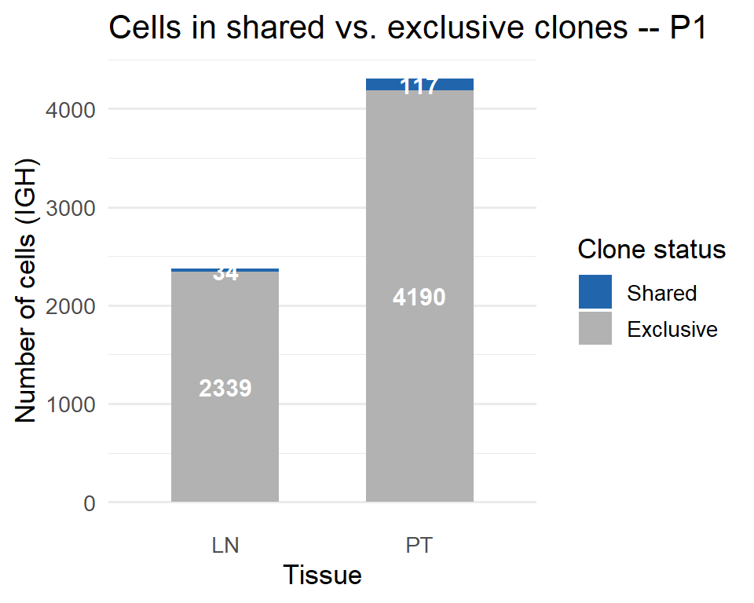

```r
shared_bar_df <- bcr_igh %>%
  dplyr::mutate(
    status = dplyr::if_else(CTstrict %in% shared_cts, "Shared", "Exclusive")
  ) %>%
  dplyr::count(tissue, status, name = "n_cells") %>%
  dplyr::mutate(
    tissue = factor(tissue, levels = c("LN", "PT")),
    status = factor(status, levels = c("Shared", "Exclusive"))
  )

p_shared_bar <- ggplot(shared_bar_df,
                       aes(x = tissue, y = n_cells, fill = status)) +
  geom_col(width = 0.55) +
  geom_text(aes(label = n_cells),
            position = position_stack(vjust = 0.5),
            color = "white", size = 4, fontface = "bold") +
  scale_fill_manual(
    values = c(Shared = "#2166AC", Exclusive = "#B2B2B2"),
    name   = "Clone status"
  ) +
  theme_minimal(base_size = 13) +
  theme(panel.grid.major.x = element_blank()) +
  labs(
    x     = "Tissue",
    y     = "Number of cells (IGH)",
    title = "Cells in shared vs. exclusive clones -- P1"
  )

p_shared_bar
```

```r
ggsave(file.path(plot_dir, "shared_cells_bar_P1.pdf"),
       p_shared_bar, width = 5, height = 4)
message("Saved: shared_cells_bar_P1.pdf")
```

```
## Saved: shared_cells_bar_P1.pdf
```

## 9.4 Attach clonal data to the Seurat object

The barcode format in the Seurat object is `ACGT...-1_P1_LN` (barcode + sample suffix, added during integration in Part 2). The format in combined_BCR after `combineBCR()` is `P1_LN_ACGT...-1_P1_LN` (sample prefix + barcode + original suffix). We harmonize these before calling `combineExpression()` by stripping the leading `<sample>_` prefix from combined_BCR barcodes.

```r
seu <- readRDS(rds_in)
message("Seurat object loaded: ", ncol(seu), " cells")
```

```
## Seurat object loaded: 7957 cells
```

```r
# Harmonize barcodes: strip leading "<sample>_" prefix from combined_BCR
combined_BCR_harmonized <- lapply(combined_BCR, function(df) {
  df$barcode <- sub(paste0("^", df$sample, "_"), "", df$barcode)
  df
})

# Overlap check before proceeding
airr_barcodes <- unique(unlist(lapply(combined_BCR_harmonized,
                                       function(x) x$barcode)))
n_overlap <- sum(colnames(seu) %in% airr_barcodes)
message("Barcode overlap (Seurat intersect AIRR): ", n_overlap, " / ", ncol(seu))
```

```
## Barcode overlap (Seurat intersect AIRR): 5446 / 7957
```

```r
if (n_overlap == 0) {
  stop(
    "Zero overlap after barcode harmonization.\n",
    "Check that cell_id format in Step 8 TSVs matches Seurat colnames.\n",
    "Example Seurat names: ", paste(head(colnames(seu), 3), collapse = ", "), "\n",
    "Example AIRR barcodes: ", paste(head(airr_barcodes, 3), collapse = ", ")
  )
}

# Add a 'sample' column to Seurat metadata for combineExpression grouping.
# Seurat cell names look like "ACGT...-1_P1_LN". We need the sample label to
# match the names of combined_BCR_harmonized (e.g. "P1_LN", "P1_PT").
# We extract the suffix after the last "-1_" by matching known sample IDs.
sample_ids <- names(combined_BCR_harmonized)
seu$sample <- NA_character_
for (sid in sample_ids) {
  seu$sample[grepl(paste0("_", sid, "$"), colnames(seu))] <- sid
}
message("Seurat sample labels:")
```

```
## Seurat sample labels:
```

```r
print(table(seu$sample, useNA = "ifany"))
```

```
##
## P1_LN P1_PT
##  2292  5665
```

```r
# Run combineExpression
# proportion = TRUE is required so Frequency is stored as a proportion.
# The cloneType bins (Rare/Small/Medium/Large/Hyperexpanded) use proportion
# thresholds (0.0001 / 0.001 / 0.01 / 0.1 / 1). With proportion = FALSE,
# raw counts are stored and every clone exceeds the 0.1 threshold, collapsing
# all cells into "Hyperexpanded".
# group.by is intentionally omitted: in scRepertoire v2, combining group.by
# with proportion = TRUE causes frequencies to be calculated incorrectly,
# also resulting in all cells landing in "Hyperexpanded".
seu_scRep <- combineExpression(
  combined_BCR_harmonized,
  sc         = seu,
  cloneCall  = "strict",
  proportion = TRUE,
  filterNA   = FALSE
)

message("combineExpression() complete.")
```

```
## combineExpression() complete.
```

```r
message("New metadata columns added:")
```

```
## New metadata columns added:
```

```r
new_cols <- setdiff(colnames(seu_scRep@meta.data), colnames(seu@meta.data))
print(new_cols)
```

```
## [1] "barcode"   "CTgene"    "CTnt"      "CTaa"      "CTstrict"  "Frequency"
## [7] "cloneType"
```

```r
# Confirm CTstrict is present
if (!"CTstrict" %in% colnames(seu_scRep@meta.data)) {
  warning("CTstrict column not found in Seurat metadata. ",
          "Check that cloneCall = 'strict' matches the combined_BCR columns.")
} else {
  n_with_ct <- sum(!is.na(seu_scRep$CTstrict))
  message("Cells with CTstrict assigned: ", n_with_ct, " / ", ncol(seu_scRep))
}
```

```
## Cells with CTstrict assigned: 5446 / 7957
```

```r
# Save
saveRDS(seu_scRep, file.path(rds_dir, "integrated_S9_scRep.rds"))
message("Saved: integrated_S9_scRep.rds")
```

```
## Saved: integrated_S9_scRep.rds
```

## 9.5 Single-cell visualizations

### 9.5.1 Clonal network on UMAP

We first plot all connections across the whole object, then filter to a single cluster of interest using `filter.identity`. This is useful for asking which other clusters share clones with, say, the GC or plasma cell population.

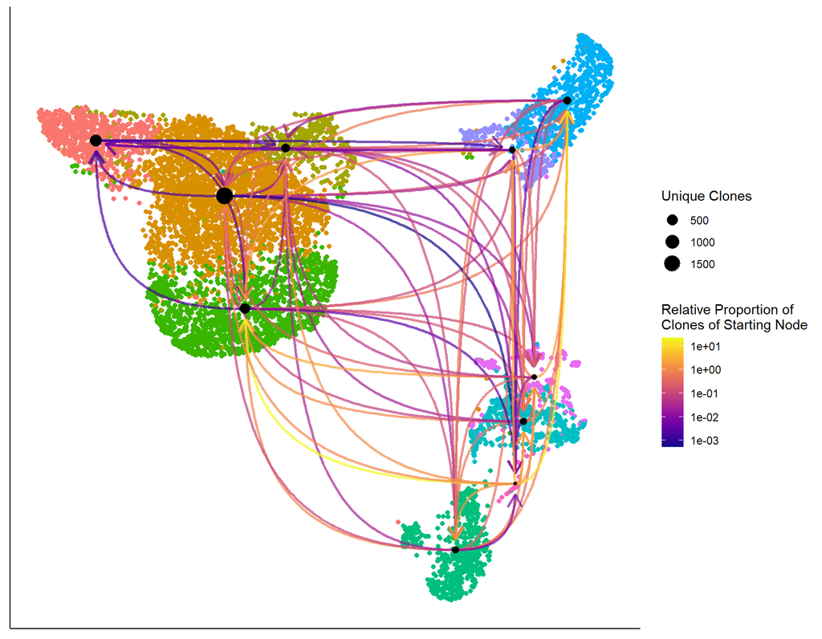

```r
set.seed(42)  # ensures reproducibility of clonalNetwork() force-directed layout (igraph is stochastic)
# Full network -- all clusters
p_net_all <- clonalNetwork(
  seu_scRep,
  reduction       = "umap",
  identity        = "cell_type",
  filter.clones   = NULL,
  filter.identity = NULL,
  cloneCall       = "strict"
)

p_net_all
```

```r
ggsave(file.path(plot_dir, "clonal_network_all.pdf"),
       p_net_all, width = 9, height = 7)
message("Saved: clonal_network_all.pdf")
```

```
## Saved: clonal_network_all.pdf
```

Now filter to a single cluster of interest. Replace `"PC"` below with whichever cell type you want to examine. The plot will show only the connections involving that cluster.

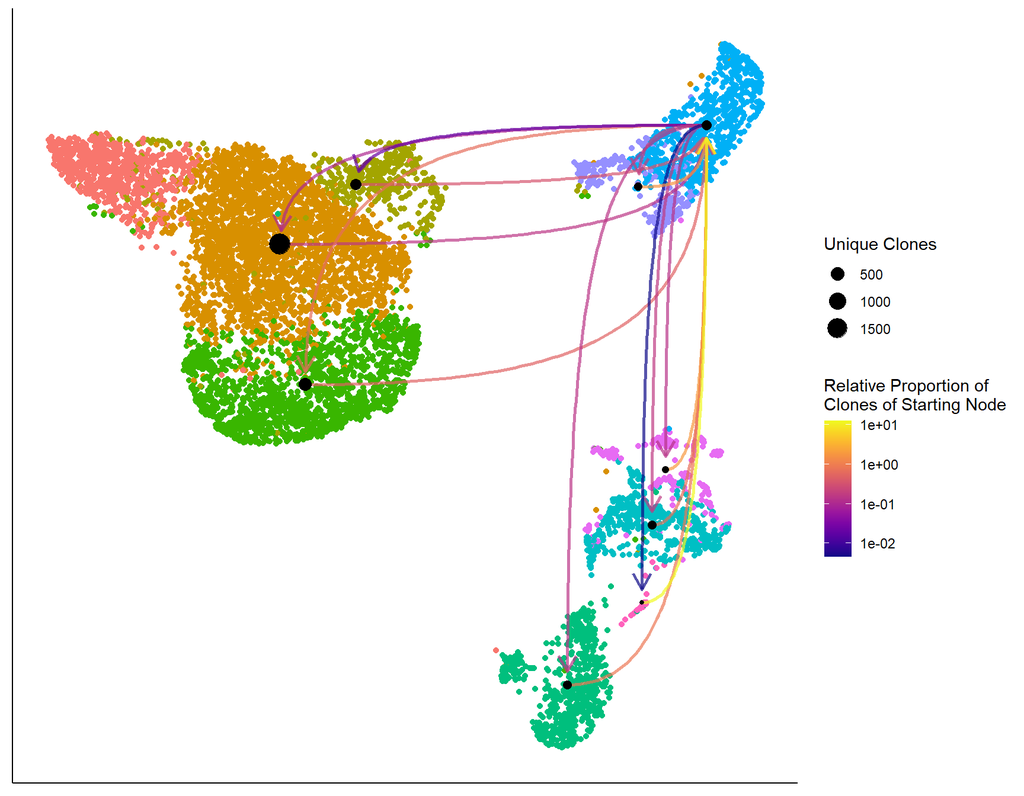

```r
set.seed(42)  # ensures reproducibility of clonalNetwork() force-directed layout (igraph is stochastic)
# Replace "PC" with your cluster of interest
cluster_of_interest <- "PC"

p_net_filtered <- clonalNetwork(
  seu_scRep,
  reduction       = "umap",
  identity        = "cell_type",
  filter.identity = cluster_of_interest,
  filter.clones   = NULL,
  cloneCall       = "strict"
)

p_net_filtered
```

```r
ggsave(file.path(plot_dir,
                 paste0("clonal_network_", cluster_of_interest, ".pdf")),
       p_net_filtered, width = 9, height = 7)
message("Saved: clonal_network_", cluster_of_interest, ".pdf")
```

```
## Saved: clonal_network_PC.pdf
```

### 9.5.2 Clonal occupancy by cluster

Note: `clonalOccupy()` was renamed to `occupiedscRepertoire()` in scRepertoire v2.0. If you get a “could not find function” error for one, use the other.

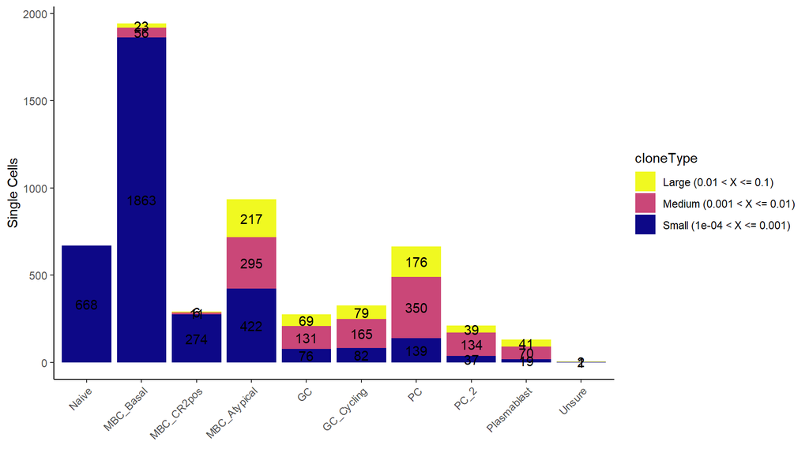

```r
# Set cell_type factor levels to control x-axis order
cluster_order <- c(
  "Naive", "MBC_Basal", "MBC_CR2pos", "MBC_Atypical",
  "GC", "GC_Cycling", "PC", "PC_2", "Plasmablast", "Unsure"
)

seu_scRep$cell_type <- factor(seu_scRep$cell_type, levels = cluster_order)

p_occupy <- occupiedscRepertoire(
  seu_scRep,
  x.axis     = "cell_type",
  proportion = FALSE,
  label      = TRUE
)

p_occupy +
  theme(axis.text.x = element_text(angle = 45, hjust = 1))
```

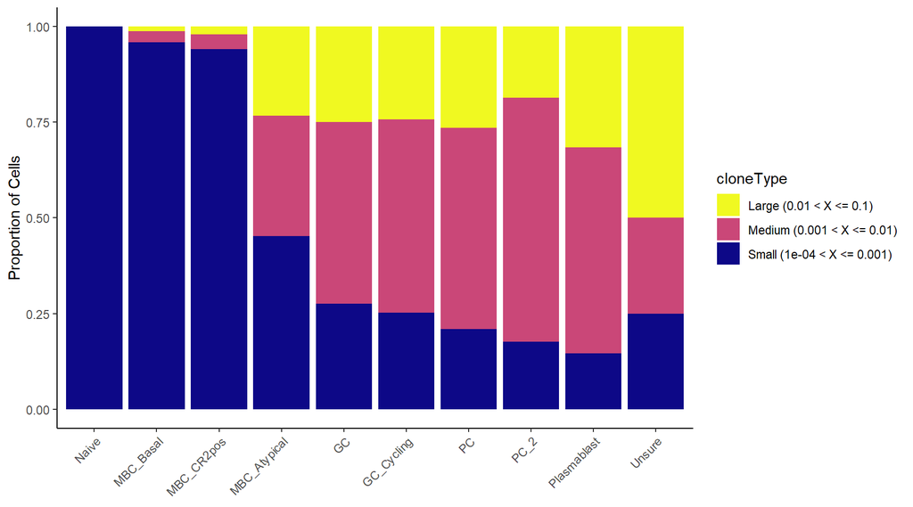

```r
ggsave(file.path(plot_dir, "clonal_occupy_counts.pdf"),
       p_occupy + theme(axis.text.x = element_text(angle = 45, hjust = 1)),
       width = 9, height = 5)

# Proportion version -- useful when cluster sizes differ greatly
p_occupy_prop <- occupiedscRepertoire(
  seu_scRep,
  x.axis     = "cell_type",
  proportion = TRUE,
  label      = FALSE
)

p_occupy_prop +
  theme(axis.text.x = element_text(angle = 45, hjust = 1))
```

```r
ggsave(file.path(plot_dir, "clonal_occupy_proportion.pdf"),
       p_occupy_prop + theme(axis.text.x = element_text(angle = 45, hjust = 1)),
       width = 9, height = 5)

message("Saved: clonal_occupy_counts.pdf and clonal_occupy_proportion.pdf")
```

```
## Saved: clonal_occupy_counts.pdf and clonal_occupy_proportion.pdf
```

## 9.6 Shared clone dot plot

- **Color** – dominant heavy chain isotype for that clone x cluster combination
- **Shape** – tissue of origin: circle = LN only, square = PT only, triangle = cells from both LN and PT found in that cluster
- **Size** – number of cells in that clone x cluster combination

Only clones with at least one cell in both LN and PT (after restricting to cells with a valid `cell_type` annotation) are shown.

### 9.6a Color palette and helper functions

```r
# Isotype colors -- consistent with the donut palette in Step 8
isotype_colors <- c(
  IGHD  = "#E41A1C",
  IGHM  = "#377EB8",
  IGHG1 = "#4DAF4A",
  IGHG2 = "#984EA3",
  IGHG3 = "#FF7F00",
  IGHG4 = "#FFFF33",
  IGHA1 = "#A65628",
  IGHA2 = "#F781BF"
)

isotype_priority <- c("IGHG1", "IGHG2", "IGHG3", "IGHG4",
                      "IGHA1", "IGHA2", "IGHD",  "IGHM")

# For each clone x cluster, pick the most common isotype.
# Ties are broken by the priority order above (IgG first, then IgA, IgD, IgM).
pick_dominant_isotype <- function(x) {
  x <- x[!is.na(x) & x != "IGHE"]
  if (length(x) == 0) return(NA_character_)
  tab  <- table(x)
  mx   <- max(tab)
  tied <- names(tab)[tab == mx]
  if (length(tied) == 1) return(tied)
  tied <- intersect(isotype_priority, tied)
  if (length(tied) > 0) return(tied[1])
  sort(names(tab)[tab == mx])[1]
}
```

### 9.6b Build the plot data

```r
# Use only heavy chain rows that have a valid CTstrict, cell_type, and isotype
bcr_plot <- bcr_all %>%
  dplyr::filter(
    locus     == "IGH",
    !is.na(CTstrict),  CTstrict  != "",
    !is.na(cell_type), cell_type != "",
    !is.na(c_call),    c_call    != "",
    c_call    != "IGHE"
  ) %>%
  dplyr::mutate(
    tissue = dplyr::case_when(
      sample_id == "P1_LN" ~ "LN",
      sample_id == "P1_PT" ~ "PT",
      TRUE ~ NA_character_
    )
  ) %>%
  dplyr::filter(!is.na(tissue))

# Identify clones present in both LN and PT
shared_cts_p1 <- bcr_plot %>%
  dplyr::group_by(CTstrict) %>%
  dplyr::summarise(
    has_LN = any(tissue == "LN"),
    has_PT = any(tissue == "PT"),
    .groups = "drop"
  ) %>%
  dplyr::filter(has_LN & has_PT) %>%
  dplyr::pull(CTstrict)

message("Shared CTstrict clones with cell type annotation: ",
        length(shared_cts_p1))
```

```
## Shared CTstrict clones with cell type annotation: 23
```

```r
# Collapse to one row per (CTstrict x cell_type)
plot_df <- bcr_plot %>%
  dplyr::filter(CTstrict %in% shared_cts_p1) %>%
  dplyr::group_by(CTstrict, cell_type) %>%
  dplyr::summarise(
    Count       = dplyr::n(),
    has_LN_here = any(tissue == "LN"),
    has_PT_here = any(tissue == "PT"),
    ccall_dom   = pick_dominant_isotype(c_call),
    .groups = "drop"
  ) %>%
  dplyr::mutate(
    Shape = dplyr::case_when(
      has_LN_here & has_PT_here ~ "Both",
      has_PT_here               ~ "PT",
      has_LN_here               ~ "LN"
    ),
    ccall_dom  = factor(ccall_dom, levels = isotype_priority),
    cell_type  = factor(cell_type, levels = cluster_order),
    Count_plot = pmin(pmax(Count, 1L), max(Count))
  ) %>%
  dplyr::filter(!is.na(Shape), !is.na(ccall_dom))

# Order clones by total cell count -- largest clone at the top of the y axis
clone_order_tbl <- plot_df %>%
  dplyr::group_by(CTstrict) %>%
  dplyr::summarise(total_cells = sum(Count), .groups = "drop") %>%
  dplyr::arrange(dplyr::desc(total_cells))

plot_df <- plot_df %>%
  dplyr::mutate(CloneID = factor(CTstrict, levels = clone_order_tbl$CTstrict))

message("Plot data: ", dplyr::n_distinct(plot_df$CTstrict),
        " clones x ", dplyr::n_distinct(plot_df$cell_type), " clusters")
```

```
## Plot data: 23 clones x 6 clusters
```

### 9.6c Build and save the plot

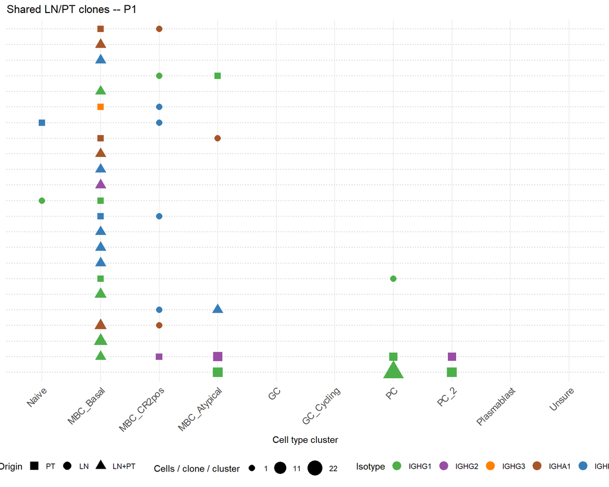

```r
# Horizontal dotted guide lines -- one per clone row
y_lines <- seq_along(levels(plot_df$CloneID))

# Dynamic size scale: upper limit is the actual max cell count in the data
max_count <- max(plot_df$Count)
mid_count <- round(max_count / 2)

p_shared <- ggplot(plot_df,
                   aes(x     = cell_type,
                       y     = CloneID,
                       color = ccall_dom,
                       shape = Shape,
                       size  = Count_plot)) +
    geom_hline(yintercept = y_lines,
               linetype = "dotted", color = "grey70", linewidth = 0.4) +
    geom_point(stroke = 0.8) +
    scale_x_discrete(limits = cluster_order, drop = FALSE) +
    scale_color_manual(values = isotype_colors, name = "Isotype") +
    scale_shape_manual(
      values = c(PT = 15, LN = 16, Both = 17),
      breaks = c("PT", "LN", "Both"),
      labels = c(PT = "PT", LN = "LN", Both = "LN+PT"),
      name   = "Origin"
    ) +
    scale_size_continuous(
      limits = c(1, max_count),
      range  = c(3, 8),
      breaks = c(1, mid_count, max_count),
      labels = c("1", as.character(mid_count), as.character(max_count)),
      name   = "Cells / clone / cluster"
    ) +
    theme_minimal() +
    theme(
      legend.position    = "bottom",
      axis.text.x        = element_text(angle = 45, hjust = 1, size = 11),
      axis.text.y        = element_blank(),
      axis.ticks.y       = element_blank(),
      panel.grid.major.y = element_blank()
    ) +
    labs(
      x     = "Cell type cluster",
      y     = NULL,
      title = "Shared LN/PT clones -- P1"
    ) +
    guides(
      color = guide_legend(override.aes = list(size = 4)),
      shape = guide_legend(override.aes = list(size = 4)),
      size  = guide_legend(override.aes = list(shape = 16))
    )

p_shared
```

```r
ggsave(file.path(plot_dir, "shared_clones_dotplot_P1.pdf"),
       p_shared, width = 10, height = 8)
message("Saved: shared_clones_dotplot_P1.pdf")
```

```
## Saved: shared_clones_dotplot_P1.pdf
```

# Going further – other scRepertoire analyses

Part 3 covers the analyses performed in the accompanying paper. scRepertoire offers several additional analyses that may be useful depending on your dataset. These are not run here – with two samples many are underpowered – but are straightforward to add.

**Clonal diversity** – compare Shannon entropy, inverse Simpson, Gini coefficient, and other indices across samples. Most informative when comparing many samples or conditions:

```r
clonalDiversity(combined_BCR, cloneCall = "strict", metric = "shannon")
clonalDiversity(combined_BCR, cloneCall = "strict", metric = "inv.simpson")
```

**V gene usage** – visualize heavy chain V gene usage as a bar chart or heatmap, or compare V-J pairings. Useful for identifying biased gene usage in expanded clones:

```r
vizGenes(combined_BCR, x.axis = "IGHV", plot = "barplot",
         summary.fun = "proportion")
percentVJ(combined_BCR, chain = "IGH", summary.fun = "percent")
```

**Clonal proportion** – rank-based view of how much repertoire space is occupied by the top 10, top 100, top 1000 clones:

```r
clonalProportion(combined_BCR, cloneCall = "strict")
```

**Highlight specific clones on UMAP** – pin a clone of interest and see where its cells sit across the transcriptomic landscape:

```r
seu_scRep <- highlightClones(seu_scRep, cloneCall = "strict",
                              sequence = c("your_CTstrict_id"))
DimPlot(seu_scRep, group.by = "highlight")
```

**Alluvial plot** – trace how clones flow across multiple categorical variables (e.g. tissue, cell type, patient). Requires at least three well-populated categories to be interpretable:

```r
alluvialClones(seu_scRep, clone.call = "strict",
               y.axes = c("sample", "cell_type"))
```

**Chord diagram** – visualize the number of shared clones between clusters as a circular diagram:

```r
library(circlize)
vizCirclize(seu_scRep, group.by = "cell_type")
```

For complete documentation and examples see the scRepertoire vignettes at https://www.borch.dev/uploads/screpertoire/.

# Summary

[output not shown]

*Part 3 complete. All BCR analysis outputs (per-sample annotation, clonal trees, cross-sample sharing) and GEX outputs (integration, cell type annotation, UMAP) are now in a single annotated Seurat object ready for downstream statistical analysis and figure preparation.*